# 1. Introduction

## 3.2 Analysis

The maps in Block 50 and 51 below show the proportion of hate crimes per one million people in 2008 and the proportion of hate crimes per one million people in 2016, respectively. In both of the maps, there does not seem to be a noticeable pattern about where the hate crimes tend to be concentrated as there are counties with a high proportion of hate crimes in all parts of the state.

The code in Block 54 calculates the correlation between the proportion of hate crimes per one million people in 2008 and the percentage of Republican voters by county in 2008, and the code in Block 55 calculates the correlation between the proportion of hate crimes per one million people in 2016 and the percentage of Republican voters by county in 2016. The scatterplots for 2008 and 2016 are visualized in Blocks 56 and 57, respectively with regression lines placed on top of the scatterplots.

One can see that the scatterplot for 2008 (Block 56) has several clear outliers corresponding to counties where the number of hate crimes per one million people was greater than 100. Even when these outliers are removed, the correlation between the proportion of hate crimes per one million people in 2008 and the percentage of Republican voters by county in 2008 is still non-significant (p = 0.144).

```
(-13914886.987877833,
 -12647417.311524622,
 3766456.955722065,
 5228877.504468495)
```

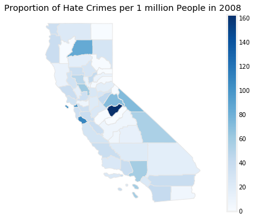

```python
# Create a map displaying hate crimes per 1 million people in 2008
fig, ax = plt.subplots(1, figsize=(10,6))
map_data.plot(column='Prop_2008', cmap='Blues', linewidth=1, ax=ax, edgecolor='0.9', legend = True)
ax.set_title('Proportion of Hate Crimes per 1 million People in 2008')
ax.axis('off')
```

```
(-13914886.987877833,
 -12647417.311524622,
 3766456.955722065,
 5228877.504468495)
```

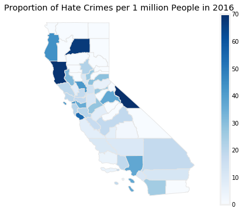

```python
# Create a map displaying hate crimes per 1 million people in 2016
fig, ax = plt.subplots(1, figsize=(10,6))
map_data.plot(column='Prop_2016', cmap='Blues', linewidth=1, ax=ax, edgecolor='0.9', legend = True)
ax.set_title('Proportion of Hate Crimes per 1 million People in 2016')
ax.axis('off')
```

```
(-13914886.987877833,
 -12647417.311524622,
 3766456.955722065,
 5228877.504468495)
```

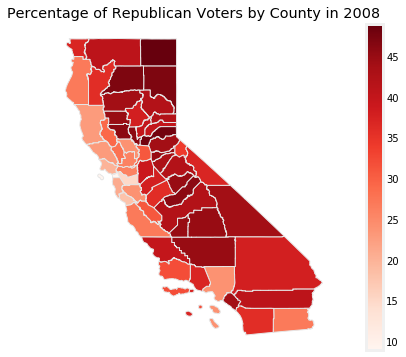

```python
# Create a map the percentage of Republican voters by county in 2008
fig, ax = plt.subplots(1, figsize=(10,6))
map_data.plot(column='Prop_Rep_2008', cmap='Reds', linewidth=1, ax=ax, edgecolor='0.9', legend = True)
ax.set_title('Percentage of Republican Voters by County in 2008')
ax.axis('off')
```

```
(-13914886.987877833,
 -12647417.311524622,
 3766456.955722065,
 5228877.504468495)
```

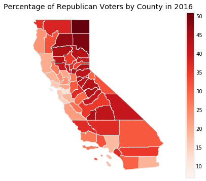

```python
# Create a map the percentage of Republican voters by county in 2016
fig, ax = plt.subplots(1, figsize=(10,6))
map_data.plot(column='Prop_Rep_2016', cmap='Reds', linewidth=1, ax=ax, edgecolor='0.9', legend = True)
ax.set_title('Percentage of Republican Voters by County in 2016')
ax.axis('off')
```

```python
# Correlation between the number of hate crimes per million people and the voter registration data in 2008
stats.spearmanr(map_data['Prop_2008'], map_data['Prop_Rep_2008'])
```

```
SpearmanrResult(correlation=-0.23473197047441033, pvalue=0.07612563631985433)
```

```python
# Correlation between the number of hate crimes per million people and the voter registration data in 2016
stats.spearmanr(map_data['Prop_2016'], map_data['Prop_Rep_2016'])
```

```
SpearmanrResult(correlation=-0.4535957645216323, pvalue=0.0003489468480844098)
```

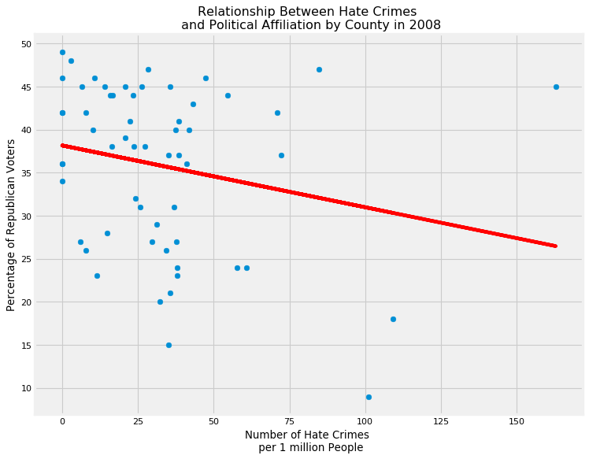

```python
# Scatterplot showing the number of hate crimes per million people and the voter registration data in 2008
figure(figsize=(10, 8), dpi=80)
m, b = np.polyfit(map_data['Prop_2008'], map_data['Prop_Rep_2008'], 1)
plt.plot(map_data['Prop_2008'], m*map_data['Prop_2008']+b, color='red')
plt.scatter(map_data['Prop_2008'], map_data['Prop_Rep_2008'], alpha=1)
plt.title('Relationship Between Hate Crimes \n and Political Affiliation by County in 2008')
plt.xlabel('Number of Hate Crimes \n per 1 million People')
plt.ylabel('Percentage of Republican Voters')
plt.show()
```

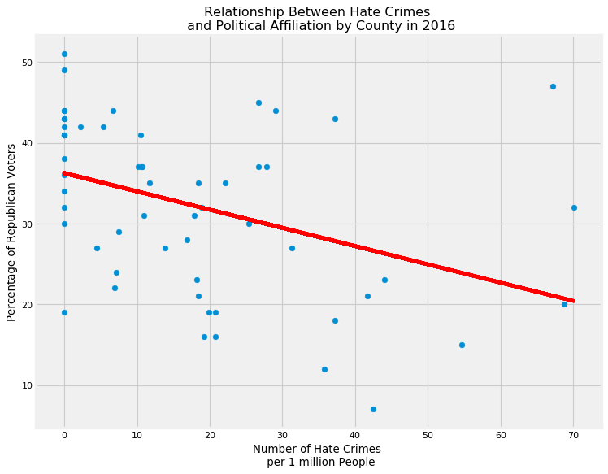

```python
# Scatterplot showing the number of hate crimes per million people and the voter registration data in 2016
figure(figsize=(10, 8), dpi=80)
m, b = np.polyfit(map_data['Prop_2016'], map_data['Prop_Rep_2016'], 1)
plt.plot(map_data['Prop_2016'], m*map_data['Prop_2016']+b, color='red')
plt.scatter(map_data['Prop_2016'], map_data['Prop_Rep_2016'], alpha=1)
plt.title('Relationship Between Hate Crimes \n and Political Affiliation by County in 2016')
plt.xlabel('Number of Hate Crimes \n per 1 million People')
plt.ylabel('Percentage of Republican Voters')
plt.show()
```

```python
# Correlation between the number of hate crimes per million people and the voter registration data in 2008 (excluding outliers)
stats.spearmanr(map_data[map_data['Prop_2008'] < 100]['Prop_2008'],
                      map_data[map_data['Prop_2008'] < 100]['Prop_Rep_2008'])
```

```
SpearmanrResult(correlation=-0.19938168756458416, pvalue=0.14445801252259882)
```

# 4. Results: How does the distribution of the types of hateful social media posts compare to the types of hate crimes?

Given that racist and prejudiced rhetoric proliferates on social media platforms [10, 11] and that some scholars have argued that social media usage and hate crimes are interconnected [12], an analysis of hateful speech online represents a fitting complement to our study of hate crime data. Our hypothesis is as follows: If hateful social media posts are tagged in a similar way to the hate crimes in the crime data set (i.e., as relating to either race/ethnicity/ancestry, sexual orientation, religion, or gender/disability), then the distribution of the types of social media posts should be similar to the distribution of the types of hate crimes. More specifically, it was noted earlier that among hate crimes committed in California from 2001 to 2020, "[t]he crimes against race/ethnicity/ancestry predominate (60.1%), followed by crimes against sexual orientation (21.1%) and religion (16.5%), and then by crimes related to gender or disability" (see the section titled "Which types of hate crimes are the most common? How have the types of hate crimes changed over time?" above). Therefore, we predict that the distribution of hateful social media posts should match the distribution of hate crime types (i.e., hateful posts about race should represent the majority of posts with posts about sexual orientation and religion being the second and third most common and with posts about gender or disability being the least common of the four types).

This section is divided into two parts: (a) "Data Cleaning" and (b) "Analysis". The "Data Cleaning" section is further subdivided into two parts. In "Step 1", a corpus of hateful tweets is created from a series of txt files and in "Step 2", the corpus is tokenized and lemmatized. The "Analysis" section contains the response to the question of interest.

# 4.1 Data Cleaning

**Step 1:** Create a corpus of hateful social media posts.

The corpus of hateful social media posts in this study comes from a series of posts from 2002 to 2017 on Stormfont, a right-wing social media site [13]. The creators in [13] have organized the posts as follows. First, a directory called "all_files" contains a series of text files. Each text file contains a unique post and the name of the text file represents the identification number of the post. Each row in a separate csv file called "annotations_metadata.csv" corresponds to a particular post, and the values in a column called "file_id" correspond to the identification numbers of the text files. In the csv file, each post is labelled as being either hateful ("hate") or as not hateful ("noHate"). The labelling was decided subjectively by the authors in [13]. The goal of this step is to select all of the posts that are tagged as being hateful and to concatenate them all into one string that can be analyzed with the natural language processing techniques that we have learned.

The "annotations_metadata.csv" file is loaded in Block 59 and the columns of interest (the file identification numbers and the labelling) are selected in Block 60. There are no null values in the csv file (Block 61), and one can see that there around 1196 posts that have been tagged as being hateful (Block 62). Block 63 changes the categorical labels to numeric values (with "hate" being changed to 1), and Block 64 saves all of the rows with hateful posts in a data frame called "hate".

Block 65 turns the "file_id" column into a list, and Block 66 adds ".txt" to the end of every file identification number. Block 67 loads the posts from the "all_files" directory. Block 68 appends the txt files from "all_files" to a list for all of the file names in Block 66 (i.e., the list called "corpus" in Block 68 contains only the files with hateful posts). The corpus is not shown here to prevent this report from becoming overly lengthy.

```python
# Load the csv file
twitter = pd.read_csv("annotations_metadata.csv")
twitter.head()
```

|  | file_id | user_id | subforum_id | num_contexts | label |
| --- | --- | --- | --- | --- | --- |
| 0 | 12834217_1 | 572066 | 1346 | 0 | noHate |
| 1 | 12834217_2 | 572066 | 1346 | 0 | noHate |
| 2 | 12834217_3 | 572066 | 1346 | 0 | noHate |
| 3 | 12834217_4 | 572066 | 1346 | 0 | hate |
| 4 | 12834217_5 | 572066 | 1346 | 0 | noHate |

```python
# Select the object type columns
df_obj = twitter.select_dtypes(include=['object']).copy()
df_obj.head()
```

|  | file_id | label |
| --- | --- | --- |
| 0 | 12834217_1 | noHate |
| 1 | 12834217_2 | noHate |
| 2 | 12834217_3 | noHate |
| 3 | 12834217_4 | hate |
| 4 | 12834217_5 | noHate |

```python
# Check that there is empty value
df_obj[df_obj.isnull().any(axis=1)]
```

|  | file_id | label |
| --- | --- | --- |

```python
# Count the values for each variables on the column "label"
df_obj["label"].value_counts()
```

```
noHate      9507
hate        1196
relation     168
idk/skip      73
Name: label, dtype: int64
```

```python
# Convert the categorical values to numerical values
cleanup_nums = {"label": {"noHate": 0, "hate": 1, "relation": 3, "idk/skip ": 4}}
df_obj = df_obj.replace(cleanup_nums)
df_obj.head()
```

|  | file_id | label |
| --- | --- | --- |
| 0 | 12834217_1 | 0 |
| 1 | 12834217_2 | 0 |
| 2 | 12834217_3 | 0 |
| 3 | 12834217_4 | 1 |
| 4 | 12834217_5 | 0 |

```python
# Select the values that are labled as "hate"
hate = df_obj[df_obj['label'] == 1 ]
hate.head()
```

|  | file_id | label |
| --- | --- | --- |
| 3 | 12834217_4 | 1 |
| 10 | 12834493_1 | 1 |
| 21 | 12849464_3 | 1 |
| 22 | 12849464_4 | 1 |
| 31 | 12855154_1 | 1 |

```python
# Convert file_ID for hate variables to a list
fileID_hate = hate["file_id"].tolist()
fileID_hate[0:10]
```

```
['12834217_4',
 '12834493_1',
 '12849464_3',
 '12849464_4',
 '12855154_1',
 '12860820_1',
 '12869018_3',
 '12883101_1',
 '12904919_1',
 '13061184_1']
```

```python
# Add a string to all the elements in the list above
string = '.txt'
fileID_hate = ["{}{}".format(i,string) for i in fileID_hate]
fileID_hate[0:10]
```

```
['12834217_4.txt',
 '12834493_1.txt',
 '12849464_3.txt',
 '12849464_4.txt',
 '12855154_1.txt',
 '12860820_1.txt',
 '12869018_3.txt',
 '12883101_1.txt',
 '12904919_1.txt',
 '13061184_1.txt']
```

```python
# Import files that are contains actual comments
path = "all_files"
all_files = os.listdir(path)
all_files[0:10]
```

```
['13458115_2.txt',
 '13367480_1.txt',
 '30422449_1.txt',
 '14651837_4.txt',
 '30527903_3.txt',
 '12870229_4.txt',
 '14053109_1.txt',
 '30399453_2.txt',
 '13591250_2.txt',
 '31713873_1.txt']
```

```python
# Define the location of the directory
path =r"all_files"

# Change the directory
os.chdir(path)

# Iterate only hate files over all the files in the directory
corpus = []
for file in fileID_hate:
    if file in os.listdir():
         with open(file) as f_input:
                corpus.append(f_input.read())
```

**Step 2:** Tokenize and lemmatize the corpus.

Block 69 converts the list called "corpus" to a string. The string is tokenized by word in Block 70, the punctuation is removed in Block 71, and the string is lowercased in Block 72. After creating a lemmatizer with nltk (Block 73) and defining a function to convert the Brown part of speech tags to the WordNet part of speech tags (Block 74), the first few tags are inspected (Block 75). Words with tags pertatining to non-functional words (e.g., determiners or DET) are removed (Block 76) and the words are then lemmatized (Block 77). The English stop words from nltk are loaded (Block 78), but a new list of stop words is created in Block 79. As the pre-defined list of stop words in nltk only contains words that are spelled correctly, it cannot remove stop words that are spelled incorrectly (e.g., "wouldn'" instead of "wouldn't"). Given that this corpus is composed of posts on the Internet, which often contain typos, it was necessary to create a customized list of stop words. Block 80 removes all of the stop words from the corpus using this customized list.

```python
# Convert a list to a sting
doc = ' '.join(corpus)
```

```python
# Separate by words
words = nltk.word_tokenize(doc)
words[0:10]
```

```
['Click',
 'below',
 'for',
 'a',
 'FREE',
 'download',
 'of',
 'a',
 'colorfully',
 'illustrated']
```

```python
# Remove punctuation
words = re.findall(r"(?:\w+|'|;|!)+", doc)
```

```python
# Lowercasing the words
words = [w.lower() for w in words]
words[0:10]
```

```
['click',
 'below',
 'for',
 'a',
 'free',
 'download',
 'of',
 'a',
 'colorfully',
 'illustrated']
```

```python
# Create a lemmatizer
lemmatizer = nltk.WordNetLemmatizer()
```

```python
# Define a function to change the tag labels
def wordnet_pos(tag):
    """Map a Brown POS tag to a WordNet POS tag."""

    table = {"N": wordnet.NOUN, "V": wordnet.VERB, "R": wordnet.ADV, "J": wordnet.ADJ}

    # Default to a noun.
    return table.get(tag[0], wordnet.NOUN)
```

```python
# Check the tags for each word
tags = nltk.pos_tag(words)
tags[0:10]
```

```
[('click', 'NN'),
 ('below', 'IN'),
 ('for', 'IN'),
 ('a', 'DT'),
 ('free', 'JJ'),
 ('download', 'NN'),
 ('of', 'IN'),
 ('a', 'DT'),
 ('colorfully', 'RB'),
 ('illustrated', 'JJ')]
```

```python
# Remove verbs which are not needed to categorize the types of hate crimes
tags = [(w, t) for (w, t) in tags if t != 'IN']
tags = [(w, t) for (w, t) in tags if t != 'CD']
tags = [(w, t) for (w, t) in tags if t != 'DT']
tags = [(w, t) for (w, t) in tags if t != 'MD']
tags = [(w, t) for (w, t) in tags if t != 'POS']
tags = [(w, t) for (w, t) in tags if t != 'PRP']
tags = [(w, t) for (w, t) in tags if t != 'PRP$']
tags = [(w, t) for (w, t) in tags if t != 'RP']
tags = [(w, t) for (w, t) in tags if t != 'WDT']
tags = [(w, t) for (w, t) in tags if t != 'WP']
tags = [(w, t) for (w, t) in tags if t != 'WRB']
tags[0:10]
```

```
[('click', 'NN'),
 ('free', 'JJ'),
 ('download', 'NN'),
 ('colorfully', 'RB'),
 ('illustrated', 'JJ'),
 ('page', 'NN'),
 ('e', 'NN'),
 ('book', 'NN'),
 ('zionist', 'NN'),
 ('engineered', 'VBD')]
```

```python
# Remove prefixes and suffixes from words through lemmatization.
words = [lemmatizer.lemmatize(w, wordnet_pos(t)) for (w, t) in tags]
words[0:10]
```

```
['click',
 'free',
 'download',
 'colorfully',
 'illustrated',
 'page',
 'e',
 'book',
 'zionist',
 'engineer']
```

```python
# These stopwords include some words that are involved to gender
stopwords = nltk.corpus.stopwords.words("english")
```

```python
# Re-define the stopwords
stopwords = ['i','me','my','myself','we','our','ours','ourselves','you',"you're","you've","you'll","you'd",'your',
             'yours','yourself','yourselves','it',"it's",'its','itself','they','them','their','theirs','themselves',
             'what','which','who','whom','this','that',"that'll",'these','those','am','is','are','was','were','be',
             'been','being','have','has','had','having','do','does','did','doing','a','an','the','and','but','if',
             'or','because','as','until','while','of','at','by','for','with','about','against','between','into',
             'through','during','before','after','above','below','to','from','up','down','in','out','on','off',
             'over','under','again','further','then','once','here','there','when','where','why','how','all','any',
             'both','each''few','more','most','other','some','such','no','nor','not','only','own','same','so',
             'than','too','very','s','t','can','will','just','don',"don't",'should',"should've",'now','d','ll','m',
             'o','re','ve','y','ain','aren',"aren't",'couldn',"couldn't",'didn',"didn't",'doesn',"doesn't",'hadn',
             "hadn't",'hasn',"hasn't",'haven',"haven't",'isn',"isn't",'ma','mightn',"mightn't",'mustn',"mustn't",
             'needn',"needn't",'shan',"shan't",'shouldn',"shouldn't",'wasn',"wasn't",'weren',"weren't",'won',
             "won't",'would','wouldn',"wouldn't"]
```

```python
# Standardizing Text: Remove tokens that don't contribute meaning.
words = [w for w in words if w not in stopwords]
```

# 4.2 Analysis

Block 81 saves the frequency distribution of the words in "fq", and Block 82 shows the most common words. One can see that the most common nouns are related to either race (e.g., "white", "black", "race", "negro") or to religion ("jew"). This corroborates with the analysis in the hate crimes data set as black people are the most heavily targeted racial group (see Block 16 above) and Jews are the most heavily targeted religious group (see Block 21 above).

```python
# Obtain the frequency distribution of the words
fq = nltk.FreqDist(w for w in words if w.isalnum())
```

```python
# Check the most frequency tokens
fq.most_common()[0:10]
```

```
[('white', 367),
 ('black', 197),
 ('get', 123),
 ('go', 113),
 ('jew', 107),
 ('people', 96),
 ('race', 83),
 ('negro', 82),
 ('see', 80),
 ('country', 67)]
```

```python
# Select the words that are meaningful towards the types of hate crime from the most frequency tokens above
# Except the tokens that are used only once
# Race/Ethnicity/Ancestry
REA = ['white','black','race','negro','country','asian','world','africa','ireland','mud','brown','jewish',
       'irish','nation','racist','african','groid','london','immigrant','uk','canada','sweden','mexican','south',
       'negroid','indian','racial','holocaust','diversity','skin','eye','hispanic','european','english','yellow',
       'ethnic','immigration','generation','america','europe','american','red','whitey','mixed','chinese',
       'marxist','mix','blood','dark','body','pakis','nonwhite','western','gene','israel','german','mongrel',
       'nigeria','history','zog','russia','tourist','ukraine','nationalist','nonwhites','arab','refugee','specie',
       'nigerian','mixing','mexico','nigs','hungarian','east','nig','england','aryan','cultural','national',
       'tribe','kike','foreigner','russian','british','france','colour','jews','dublin','border','invade','york',
       'swede','native','britain','groids','india','ghetto','nazi','polish','wiggers','blue','invasion','color',
       'poland','ukrainian','holohoax','obama','swedish','indigenous','kaffir','foreign','spic','juden','genetic',
       'kingston','negros','plymouth','birmingham','california','florida','goy','lorraine','nose','nigga',
       'switzerland','finland','invader','interracial','mulatto','eu','global','north','blond','verl','colorfully',
       'greece','hitler','texas','rapist','nordic','romania','antifa','islander','arabs','francisco','sheboon',
       'iceland','racially','soviet','slavery','stockholm','oslo','winnipeg','racism','zimbabwe','americans',
       'language','lebanese','alien','boarder','mestizo','asians','miami','ethnically','philadelphia','detroit',
       'boston','slav','blonde','roman','ju','danish','naive','italy','italian','mongrelize','igger','trudeau',
       'egyptian','jude','europa','darker','resistance','beaner','judeo','holland',]

# Religion
RE = ['jew','liberal','hell','god','muslim','zionist','evil','christian','libtard','islam','jesus','islamic','leftist',
      'libtards','religion','worship','kosher','supremacist','bless','communist','christ','civilize','lefty','son',
      'zionism','political','multiculturalism','chimpout','holy','moslem','bolshevik','rabbi','father','republic',
      'lord','church','preacher','patriot','democracy','christentum',]

# Sexual Orientation
SO = ['couple','gay','homosexual','date','homosexuality','marriage','sexual','sex','homo','faggot','pervert',
      'marry','rainbow','pride','lesbian','prostitution','straight','pedophilia','queer','craphole','identity',
      'pornography','strip','boyfriend','prostitute','bi','lust','punk',]

# Gender/Disability
GD = ['woman','ape','girl','monkey','animal','man','men','female','male','sister','mother','daughter','creature',
      'coon','education','brother','boy','primitive','wife','chimp','bitch','pig','adopt','iq','deanna','spingola',
      'lorraine','intellectual','gorilla','daddy','chick','penis','blind','horse','baboon','hearing','george',
      'mutate','pregnant','primate',]
```

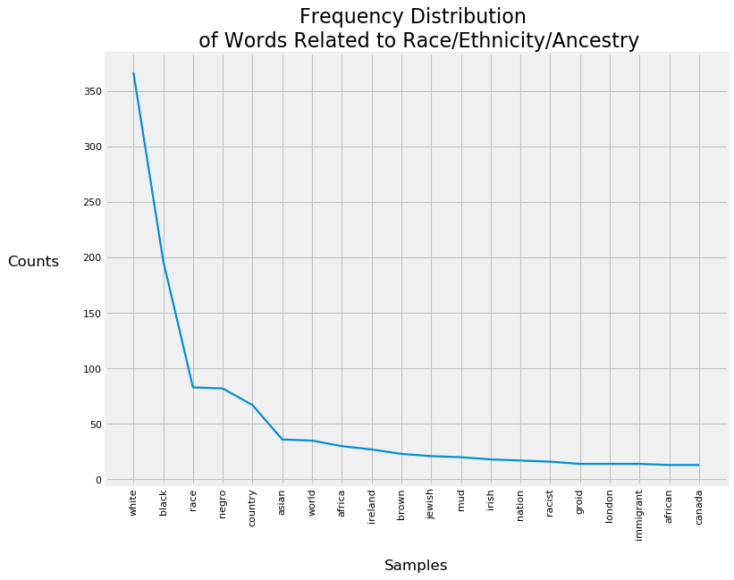

```python
# Frequently used words for Race/Ethnicity/Ancestry
figure(figsize=(10, 8), dpi=80)
rea = [w for w in words if w in REA]
fq_rea = nltk.FreqDist(w for w in rea if w.isalnum())
plt.title('Frequency Distribution \n of Words Related to Race/Ethnicity/Ancestry', fontsize=20)
plt.xlabel('Samples', fontsize=15, labelpad=20)
plt.ylabel('Counts', fontsize=15, rotation=0, labelpad=50)
fq_rea.plot(20)
```

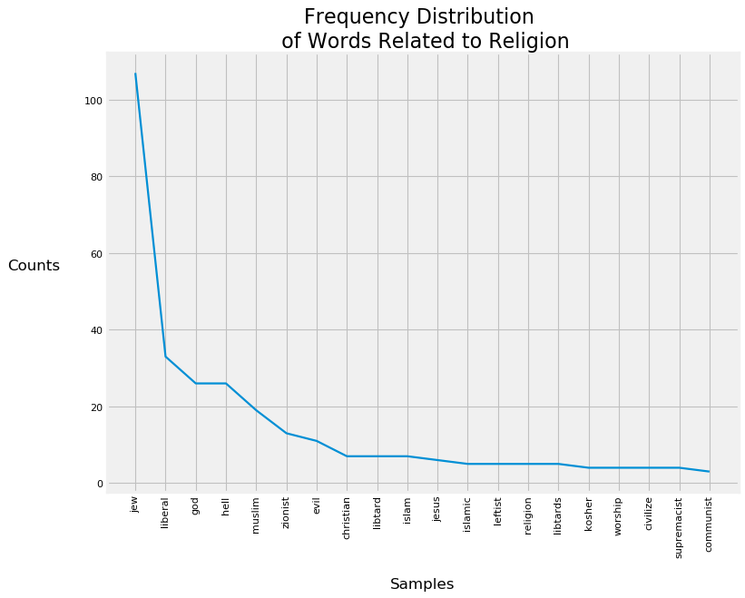

```python
# Frequently used words for Religion
figure(figsize=(10, 8), dpi=80)
re = [w for w in words if w in RE]
fq_re = nltk.FreqDist(w for w in re if w.isalnum())
plt.title('Frequency Distribution \n of Words Related to Religion', fontsize=20)
plt.xlabel('Samples', fontsize=15, labelpad=20)
plt.ylabel('Counts', fontsize=15, rotation=0, labelpad=50)
fq_re.plot(20)
```

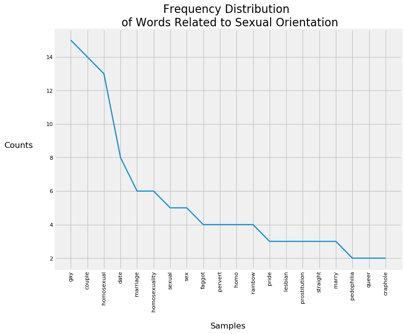

```python
# Frequently used words for Sexual Orientation/Sexual crime?assault?
figure(figsize=(10, 8), dpi=80)
so = [w for w in words if w in SO]
fq_so = nltk.FreqDist(w for w in so if w.isalnum())
plt.title('Frequency Distribution \n of Words Related to Sexual Orientation', fontsize=20)
plt.xlabel('Samples', fontsize=15, labelpad=20)
plt.ylabel('Counts', fontsize=15, rotation=0, labelpad=50)
fq_so.plot(20)
```

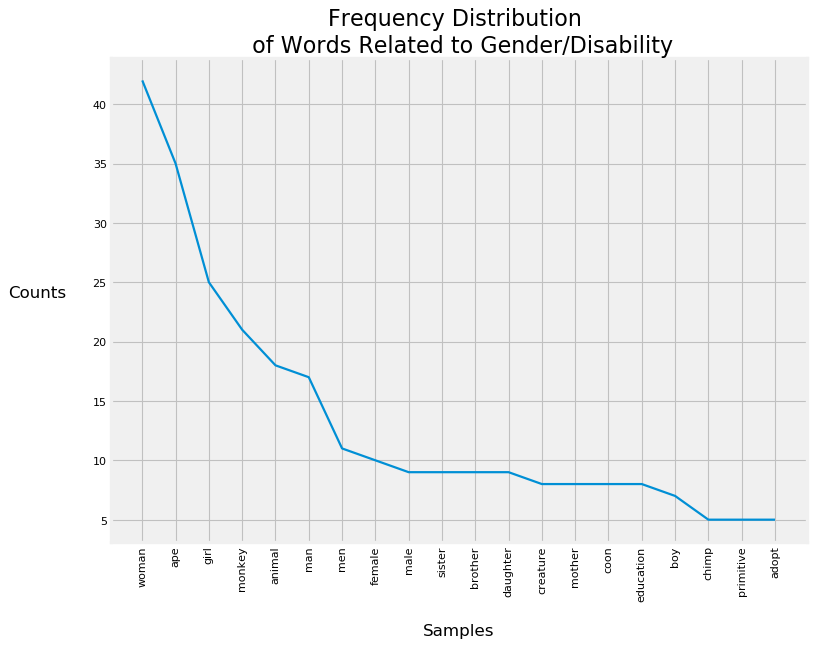

```python
# Frequently used words for Gender/Disability
figure(figsize=(10, 8), dpi=80)
gd = [w for w in words if w in GD]
fq_gd = nltk.FreqDist(w for w in gd if w.isalnum())
plt.title('Frequency Distribution \n of Words Related to Gender/Disability', fontsize=20)
plt.xlabel('Samples', fontsize=15, labelpad=20)
plt.ylabel('Counts', fontsize=15, rotation=0, labelpad=50)
fq_gd.plot(20)
```

```python
rea_count = len(rea)
print(rea_count)
re_count = len(re)
print(re_count)
so_count = len(so)
print(so_count)
gd_count = len(gd)
print(gd_count)
```

```
1832
347
125
326
```

```python
data = {'Type':['Race/Ethnicity/Ancestry', 'Religion', 'Sexual Orientation', 'Gender/Disability'],
        'Frequency':[1936, 235, 126, 322]}

# Create DataFrame
df = pd.DataFrame(data)
df
```

[output not shown]

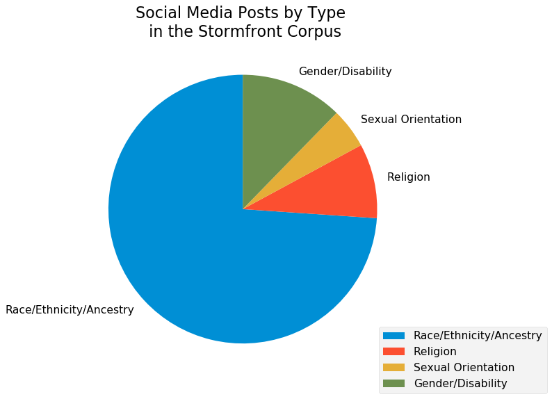

```python
# Plot a pie graph
figure(figsize=(10, 8), dpi=80)
plt.pie(df['Frequency'], labels=df['Type'],
        startangle=90, textprops={'fontsize':14})
plt.legend(bbox_to_anchor=(0.75,0.25), loc="upper left",
          bbox_transform=plt.gcf().transFigure, fontsize=14)
plt.title("Social Media Posts by Type \n in the Stormfront Corpus", fontsize=20)
plt.show()
```

# Conclusion

There were three goals of this study: (a) to conduct an exploratory data analysis on hate crime data to better understand how the nature and target of hate crimes have changed over time; (b) to test whether political affiliation is related to the geographical distribution of hate crimes; (c) to analyze social media posts using natural language processing techniques in order to figure out the connections between hateful rhetoric online and hate crimes. Our two primary data sets were a hate crimes data set with crimes in California from 2001 to 2020 and a data set with social media posts on Stormfront, a right-wing social media site. Our specific questions were as follows:

1. How have the number of hate crimes changed over time?
2. Which types of hate crimes are the most common? How have the types of hate crimes changed over time?
3. Which racial and religious groups tend to be the most targeted?
4. How is county political affiliation related to the geographical distribution of hate crimes?
5. How does the distribution of the types of hateful social media posts compare to the types of hate crimes?

Section 2 ("Results: Exploratory Data Analysis") responded to the first three questions. In response to the first question, we found that the number of hate crimes in California were at their highest in 2001, and although the number of crimes decreased from 2001 to 2014, the number has been rising ever since. This supports claims that hate crimes are rising in the United States [2, 3].

In response to the second question, we observed that hate crimes motivated by a bias against race/ethnicity/ancestry were most common overall in California. This was followed by crimes against particular religions or sexual orientations. Crimes targeted a particular gender or disability were the least common among the four types. Although the crimes against religion and sexual orientation have remained relatively constant over time, those against race/ethnicity/ancestry have fluctuated.

In response to the third question, we showed that among the racial groups that were targeted, blacks or African Americans tend to be the most targeted. Moreover, among the religious groups that were targeted, Jews and Muslims tend to be the most targeted.

Section 3 ("Results: How is county political affiliation related to the geographical distribution of hate crimes?") answered the fourth question. Our specific hypothesis was as follows: counties with a higher proportion of registered Republican voters should have a greater number of hate crimes (relative to the population of each county). We actually found that in 2008, there was no evidence of a relationship between the number of hate crimes and the proportion of Republican voters, and that in 2016, there was a negative correlation between the number of hate crimes and the proportion of Republican voters. In other words, counties with a higher proportion of registered Republican voters in 2016 had a lower number of hate crimes in the same year, which went against out hypothesis.

Given that Republican voters tend to be less commonly found in urban areas [14] and that urban areas generally have higher crime rates overall [15], it is possible that the number of hate crimes in a particular county is more related to whether the county is in an urban or rural setting rather than the voter registration statistics, as we had hypothesized.

We note that there are several limitations to the current study. First, hate crimes are often underreported [16], meaning that the hate crimes data set from the California government may be incomplete. Second, each crime in the hate crimes data set was categorized as pertaining to a single category (e.g., as being motivated by either race/ethnicity/ancestry or by gender). However, social categories like race and gender are intersectional [17], so it is possible that people may have been targeted for being part of muliple minoritized groups (e.g., individuals may have harrassed a black woman for both her race and her gender). Finally, although it is interesting that the social media data set and the hate crimes data set matched in that most of the content had to do with race/ethnicity/ancestry, these results should be interpreted with caution as this analysis cannot provide evidence for a causal link between social media posts and crime.

By analyzing hate crime data and connecting this to other relevant issues, such as politics and social media, we believe that this analysis is potentially useful for better understanding the distribution of hate crimes and for ultimately helping to mitigate the rise in hate crimes that has been observed.